# ResultTemplate

Loong Kuan

17 September 2016

## Original Data of 2 Dates

Load data.

Data from before “drift”.

```
##   Rcdminutes Temperature Humidity  Light Voltage Class
## 1         58     19.7336  37.0933  71.76 2.69964    19
## 2         58     19.6160  37.5737  97.52 2.69964    25
## 3         58     19.7728  37.1620 143.52 2.71196    24
## 4         58     20.2040  36.8871  50.60 2.69964     3
## 5         58     20.4196  36.6118 121.44 2.65143     6
```

Data from after “drfit”.

```
##         Rcdminutes Temperature Humidity   Light Voltage Class
## 1109902        465     19.8806 46.06550  964.16 2.43410    35
## 1109903        465     22.6834 37.64220  250.24 2.54901    51
## 1109904        466     24.0554 34.15320 1435.20 2.53812    22
## 1109905        466     22.3012 38.39460  478.40 2.56000    48
## 1109906        466    122.1530 -1.82116  412.16 2.13640    18
```

Histogram of the data by attributes.

```
## [1] "Plots Obtained"
```

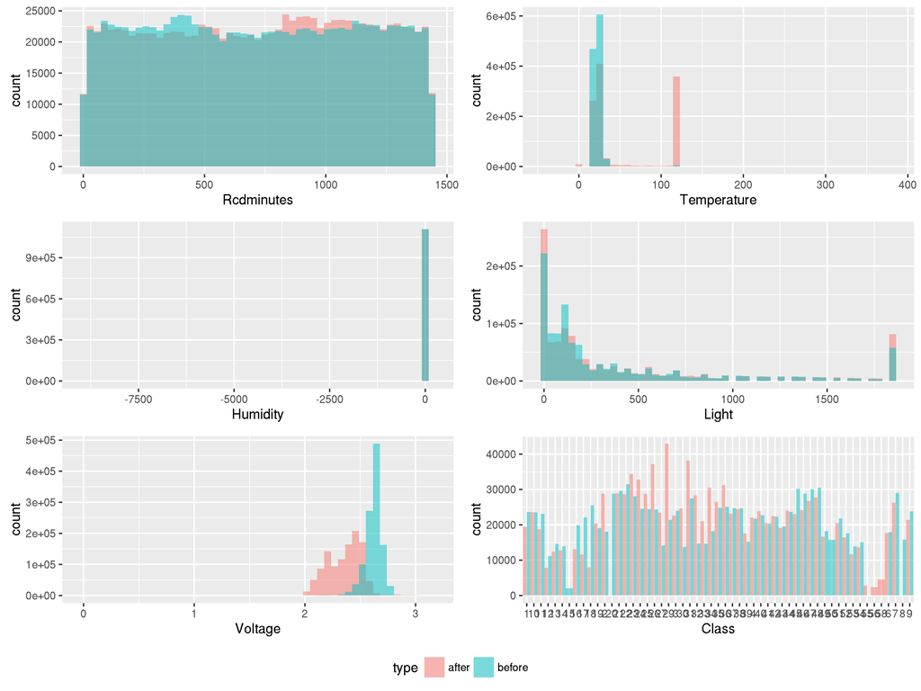

## Drift Results

The raw data of the results will be provided at the end of this document.

### Covariate Drift

The following is the results for a test of 1 Attribute. We can verify the correctness of the results by comparing them to the histograms of the attributes above.

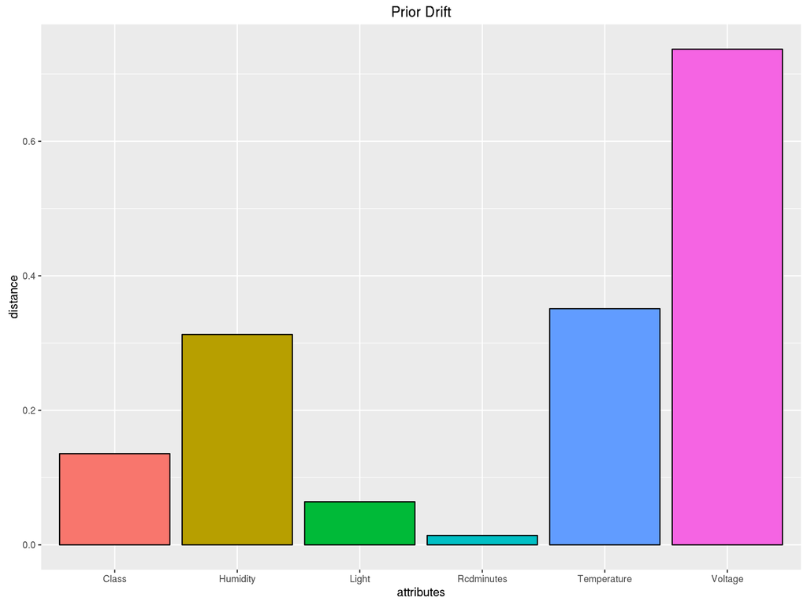

The following is the covariate results for 2 Attributes. This plot is just an exercise on how results from larger amounts of attributes might be visualised.

The plot is made by first constructing a “distance matrix” where the distance obtained for each pair of attribute is represneted.

```
##            [,1]       [,2]      [,3]      [,4]      [,5]      [,6]
## [1,] 0.00000000 0.07758169 0.1428578 0.6400661 0.3712367 1.5386742
## [2,] 0.07758169 0.00000000 0.2196088 0.6358243 0.3713124 0.7702029
## [3,] 0.14285779 0.21960878 0.0000000 0.7428104 0.3927341 0.8511786
## [4,] 0.64006610 0.31791214 0.7428104 0.0000000 0.9011416 0.7527518
## [5,] 0.74247343 0.74262479 0.3927341 0.9011416 0.0000000 1.5620168
## [6,] 0.76933709 1.54040586 1.7023572 1.5055036 0.7810084 0.0000000
```

This matrix is then plotted using Multidimensional Scaling to visualise the distances in the matrix. The final plot will then plot attributes that have a higher dirft together further apart.

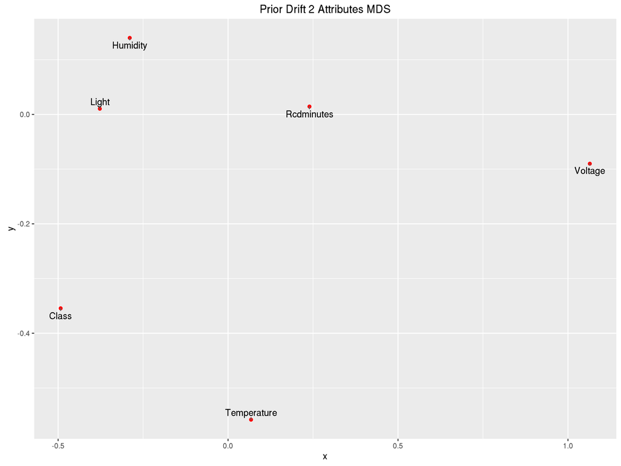

We can also plot the distance matrix as a heatmap to directly view the results. However this method only works with 2 attribute tests.

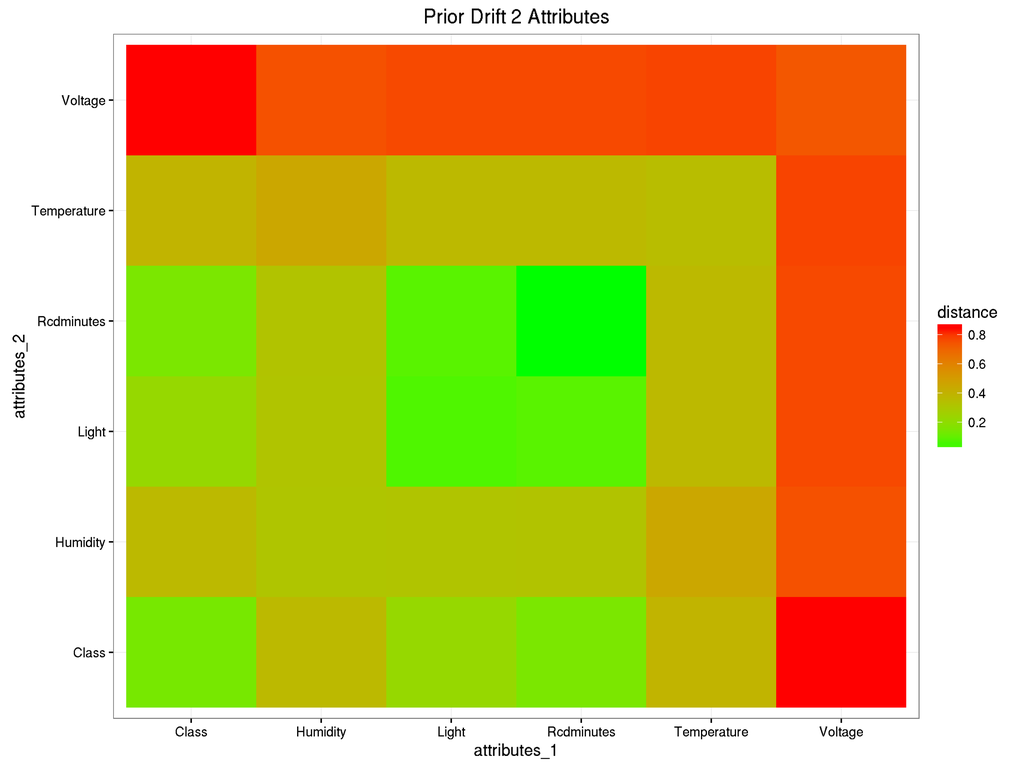

### Conditioned Covaraites (Single Attributes)

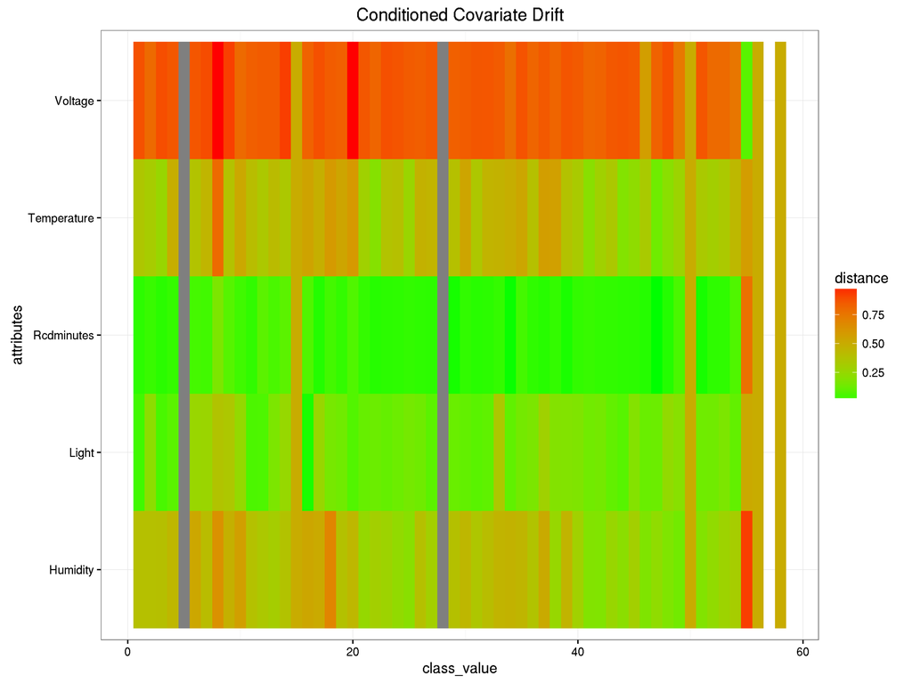

Gred Values means that the specific class does not occur in the dataset.

### Conditioned Covaraites (Pair Attributes)

```
## [1] "Plots obtained"
```

[figure not shown]

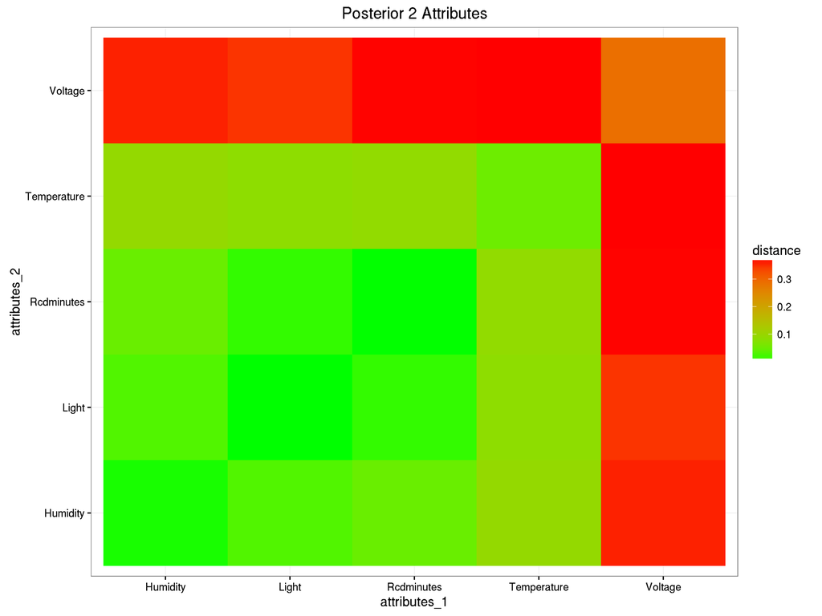

## Raw Data

https://github.com/LeeLoongKuan/DriftMapper/tree/master/data_out/martvard

## Raw Plots

https://github.com/LeeLoongKuan/DriftMapper/tree/master/DataAnalysisR/Plots